# Classifying each person’s response curve

- Show All Code
- Hide All Code
- View Source

A simulation harness for choosing how many judgments per participant

Published

September 3, 2026

## Overview

This simulation asks: how many judgments does each participant need to provide for their response curve to be correctly identified?

Each participant sees pairs of star ratings at a fixed distance apart and reports how different the two ratings feel. Their responses are plotted against the mean of each rating pair and altogether, follow the form of a curve. Competing theories of how people perceive a rating scale predict different curve shapes. We want to classify people according to curve shape, which will inform the following question: how many reference points does the participant use?

This simulation generates participants whose true underlying curve shape is known, has each participant “take the survey” and provide responses, classifies them using different statistical approaches, and counts how often the classification is right or wrong. Repeating that across settings shows how many judgments per participant are needed to achieve a minimum of 80% power and a maximum of 5% Type 1 error.

## Contents

1. **Theories and the curves they predict** — the shape library, and which account motivates each shape
2. **Quick start** — running the simulation and re-rendering this document
3. **How each participant’s data is generated** — the eleven steps, and what the number of participants does and does not change
4. **Parameter reference** — every parameter, grouped by the stage it acts on
5. The shape library in code, and three questions about it
6. The classifier, and why residual error alone is not a rule
7. One population, one confusion matrix
8. Sweeping judgments per participant and reference-point separation
9. How many judgments per participant
10. Effect of the number of participants
11. Fidelity to the real experiment
12. Summary of findings
13. Nonparametric alternatives
14. An alternative experimental design
15. Does the size of the rating scale matter?

```python
import numpy as np, pandas as pd
from scipy.optimize import curve_fit
from scipy.signal import find_peaks
from sklearn.isotonic import IsotonicRegression
import matplotlib.pyplot as plt
import seaborn as sns

sns.set_theme(style="whitegrid", palette="colorblind")
pd.set_option("display.float_format", lambda v: f"{v:0.3f}")
pd.set_option("display.width", 200)
pd.set_option("display.max_columns", 30)
pd.set_option("display.max_colwidth", None)   # show full cell text, no ellipses
rng = np.random.default_rng(20260823)
```

## 1. Theories and the curves they predict

Each shape is what a specific account of rating-scale perception predicts, and each implies a particular number of reference points. The right-hand column shows what the classifier has to tell apart from a few dozen noisy judgments.

Table 1

| Account | Predicted curve | Reference points | Source | Shape |
| --- | --- | --- | --- | --- |
| **No categorical structure** Only nominal distance matters; where a pair sits on the scale is irrelevant. | flat | 0 | the null hypothesis |  |
| **Weber's law** A fixed gap is easier to tell apart at one end of the scale than the other, with no category boundary anywhere. | monotone | 0 | classical psychophysics |  |
| **Binary bias, strict** People split ratings into positive and negative at the scale midpoint and compress differences *within* each bin, so only pairs straddling the split feel different. | unimodal, sharp peak at 3.0 | 1 | Fisher, Newman & Dhar (2018), *JCR* 45(3), 471-489 |  |
| **A single reference point elsewhere** The same mechanism, but the split sits somewhere other than the midpoint - for example a personal "4 stars or better" rule. | unimodal, peak at that rating | 1 | - |  |
| **A neutral zone** Three categories rather than two: negative, neither, positive. Pairs straddling *either* edge feel different; pairs inside the neutral zone do not. | bimodal, a peak at each edge | 2 | the three-category result in Fisher, Newman & Dhar (2018), study 8 |  |

Curves are noise-free, drawn on a 1-5 star scale. Red lines mark reference points.

**The two competing predictions are rows 3 and 5.** Fisher, Newman & Dhar report that participants spontaneously form a neutral bin, and that their unlabelled baseline condition patterned more like the three-category condition than the two-category one - but they keep the binary framing because their imbalance score sets the middle bin aside by construction. A discriminability curve settles it directly: one peak at 3.0, or two peaks at 2.5 and 3.5.

**NoteTwo accounts deliberately left out**

**Step and S-shaped curves**, in which sensitivity shifts permanently at a reference point rather than rising and returning to baseline. Binary bias predicts a peak, not a step: differences among 4s and 5s are compressed just as differences among 1s and 2s are, so sensitivity comes back down above the split. No account currently motivates a step here, so the main simulation uses peaks and step shapes are kept in §11 only as a check on what happens if that assumption is wrong.

**A reference point outside the measured window.** Midpoints are tested from `MID_LO` to `MID_HI`; a reference point beyond either end would show only one flank of its peak, which looks monotone. This is a measurement caveat rather than a theory, and it does not arise for the predictions above, whose reference points at 2.5 and 3.5 sit well inside the window. It is discussed in §5a.

**TipError terminology**

Three terms are used for two quantities, defined here for reference.

| Name | Meaning | Good value |
| --- | --- | --- |
| **Type I error** (false positive) | Function gets classified as bimodal when it is unimodal, monotonic, or flat | **≤ 0.05** (5%) |
| **Type II error** (false negative) | Function gets classified as unimodal, monotonic, or flat when it is bimodal | **≤ 0.20** (20%) |
| **Power** | Function gets classified as bimodal when it is bimodal | **≥ 0.80** (80%) |

Power and Type II error are complements: `power = 1 - Type II`. Table columns reporting *Type II* or *false negative* are minimised; columns reporting *correct*, *found*, or *power* are maximised.

## 2. Quick start

**NoteRunning the simulation and re-rendering this document**

Every parameter lives in the single `config` block in §3. Edit the values there and re-render; every table and figure in this document recomputes.

**To re-render:**

```bash
quarto render Shape_Classification_Power.qmd --to html
```

A full render takes about nine minutes. Setting `QUICK = True` in the config block coarsens the sweep grids and cuts that substantially.

**Supporting scripts.** A few analyses are too slow to run on every render. Each writes a CSV that this document reads; re-run the script if you change any Layer 1 parameter.

| Script | Runtime | Produces |
| --- | --- | --- |
| `error_grid.py` | ~12 min | the interactive explorer in §8 |
| `pair_gap_and_repeats.py` | ~5 min | the pair-gap and replication tables in §5c |
| `allocation_test.py` | ~7 min | the judgment-budget comparison in §5c |
| `hybrid_design.py` | ~4 min | the partial-replication tables in §5c |
| `noise_model.py` | ~3 min | the noise-model comparison in §11.2 |
| `scale_size_analysis.py` | ~6 min | the scale-invariance tables in §15 |
| `method_shootout.py` | ~30 s | the five-method comparison in §13.2 |
| `extended_confusion.py` | ~2 min | the step and S-curve robustness tables in §11 |

**Ground truth is available.** Every simulated participant carries their true shape and true parameters, so any new classifier can be benchmarked against the correct answer by calling `simulate_population` and comparing.

## 3. How each participant’s data is generated

All parameters live in this one block.

```python
# ---- the rating scale and stimulus grid ------------------------------------
# Participants judge pairs of ratings PAIR_GAP apart. On a 1-5 scale the lowest
# pair is 1.0 / 1.4 and the highest is 4.6 / 5.0, so the midpoints they generate
# run from 1.2 to 4.8.
SCALE_LO, SCALE_HI = 1.0, 5.0    # the rating scale itself
PAIR_GAP       = 0.4             # stars between the two ratings in a pair (§5c)
RATING_STEP    = 0.1             # granularity of the rating scale
MID_LO, MID_HI = SCALE_LO + PAIR_GAP / 2, SCALE_HI - PAIR_GAP / 2
SLIDER_MAX     = 100.0           # the 0-100 perceived-difference slider

# ---- the population --------------------------------------------------------
N_PEOPLE  = 500                  # simulated participants per condition
SHAPE_MIX = {'flat':     0.10,   # must sum to 1
             'monotone': 0.10,   # flat + monotone = people with ZERO reference points
             'unimodal': 0.40,
             'bimodal':  0.40}

# How many reference points each curve shape implies: the mapping from
# "what the curve looks like" to "the answer to the research question".
N_REFPOINTS = {'flat': 0, 'monotone': 0, 'unimodal': 1, 'bimodal': 2}

# ---- LAYER 1: what each true shape looks like ------------------------------
PEAK_W      = 0.30       # half-width of any peak  <-- read the warning in §5
JITTER_PEAK_W = 0.33     # spread of PEAK_W across people; 0.33 gives a 5th-95th
                         # percentile range of about 0.14 to 0.46 (§5a)
BASELINE    = 30.0       # slider value away from any peak
PEAK_AMP    = 30.0       # slider points added at a peak's summit
MONO_SLOPE  = 8.0        # monotone: size of the slope, slider points per star
MONO_DIR    = 'decreasing'   # 'decreasing' = Weber's law; 'increasing' = the
                             # reverse. Inert either way: the fitted line has a
                             # free sign, so the two classify identically.
BASE_SLOPE  = 0.0        # Weber trend UNDERNEATH the peaks; 0 = flat baseline (§11.6)

# ---- LAYER 1: person-to-person variation in those parameters ---------------
# Peak locations are drawn from a bell curve: most likely at PEAK_CENTRE, less
# and less likely the further away you go. Truncated so the peak stays visible.
PEAK_CENTRE  = 3.00      # the scale midpoint, which is where 1 predicts the split
PEAK_LOC_SD  = 0.35      # spread of reference-point LOCATION across people.
                         # Deliberately larger than PEAK_W: people differ more in
                         # WHERE their line sits than any one person wavers.
JITTER_AMP   = 0.20      # SD of peak amplitude, as a fraction of PEAK_AMP
JITTER_SLOPE = 0.20      # SD of monotone slope, as a fraction of MONO_SLOPE

# ---- LAYER 2: measurement noise --------------------------------------------
SLIDER_SD = 12.0         # SD of a single slider response, AT THE TOP OF A PEAK
NOISE_MODEL = 'proportional'  # 'constant' | 'proportional' | 'floor'.
                         # 'constant' is the worst case and is reported as a
                         # bound in §11.2 rather than as the headline.
NOISE_FLOOR = 3.0        # smallest response SD, used by the 'floor' model
REPS      = 1            # times each midpoint is asked (see §11.5)

# ---- the classifier --------------------------------------------------------
TIE_W_TO_GRID = True     # stop fitted peaks being narrower than the x-spacing (§6)
FIT_BASELINE_SLOPE = True    # give the peak shapes their own slope term, so a Weber
                             # tilt under the peaks cannot force a spurious second
                             # peak. Costs ~2 points when there is no tilt; saves
                             # ~80 when there is. See §6d.
FIT_TOL       = 1e-4     # least-squares convergence tolerance (see the note in §6)
FIT_MAXFEV    = 2000     # hard cap on function evaluations per fit
IC_RULE       = 'BIC'    # 'BIC' | 'AICc' | 'AIC'  -- §6b compares them

# ---- what to sweep ---------------------------------------------------------
QUICK    = False                           # True = coarser grids, much faster
N_POINTS = [20, 30] if QUICK else [20, 30, 37]   # 37 = every realisable midpoint
SEP_GRID = [0.6, 1.2] if QUICK else [0.6, 0.8, 1.0, 1.2]
N_PEOPLE_GRID = [200, 300, 400, 500]       # for the §10 robustness check
RUN_NONPARAMETRIC = False                  # slow; see §12
```

[output not shown]

### The eleven steps

The simulation runs in three layers. Layer 1 builds a participant, Layer 2 generates the responses that participant would give, and Layer 3 analyses those responses without access to Layer 1.

**Layer 1 — build one participant.**

1. **Draw their curve shape** from `SHAPE_MIX`. The probabilities are *not* equal; the current values appear in the diagram below.
2. **Draw the parameters that shape needs.** What gets drawn depends on the shape, because the shapes do not all have reference points:

   | shape | reference points | drawn for this participant |
   | --- | --- | --- |
   | `flat` | none | nothing; the curve sits at `BASELINE` |
   | `monotone` | none | a slope |
   | `unimodal` | one | the location of that reference point, plus a peak height |
   | `bimodal` | two | the midpoint of the pair, plus a peak height; the two are placed at ± half the neutral-zone width |

   Locations come from a bell curve centred on `PEAK_CENTRE` with SD `PEAK_LOC_SD`, truncated so every reference point stays inside the measured window. Peak height is `PEAK_AMP` scaled by a draw with spread `JITTER_AMP`.
3. **Evaluate the curve.** The result is a smooth, noiseless function over the whole rating range: the ground truth, used again only at step 11.

**Layer 2 — generate their responses.**

4. **Choose the midpoints:** `N_POINTS` values evenly spaced from `MID_LO` to `MID_HI`.
5. **Read the true curve** at each midpoint.
6. **Add measurement noise**, sized by `SLIDER_SD` and `NOISE_MODEL`.
7. **Clip to the slider range**, 0 to `SLIDER_MAX`. The result is a scatter of points — the only object a real study produces.

**Layer 3 — classify, blind.**

8. **Fit all four candidate shapes** by least squares.
9. **Score each fit** with `IC_RULE`, which charges a shape for the number of parameters it uses.
10. **Lowest score wins**, giving a predicted shape and hence a predicted number of reference points.
11. **Compare with step 1** and record whether it was right.

Figure 1: The eleven steps of the simulation, with the branch probabilities read live from SHAPE_MIX. Layer 1 builds a participant and their noiseless curve; Layer 2 turns that curve into the scatter a real study would collect; Layer 3 classifies the scatter without access to the curve. Only step 11 compares the two.

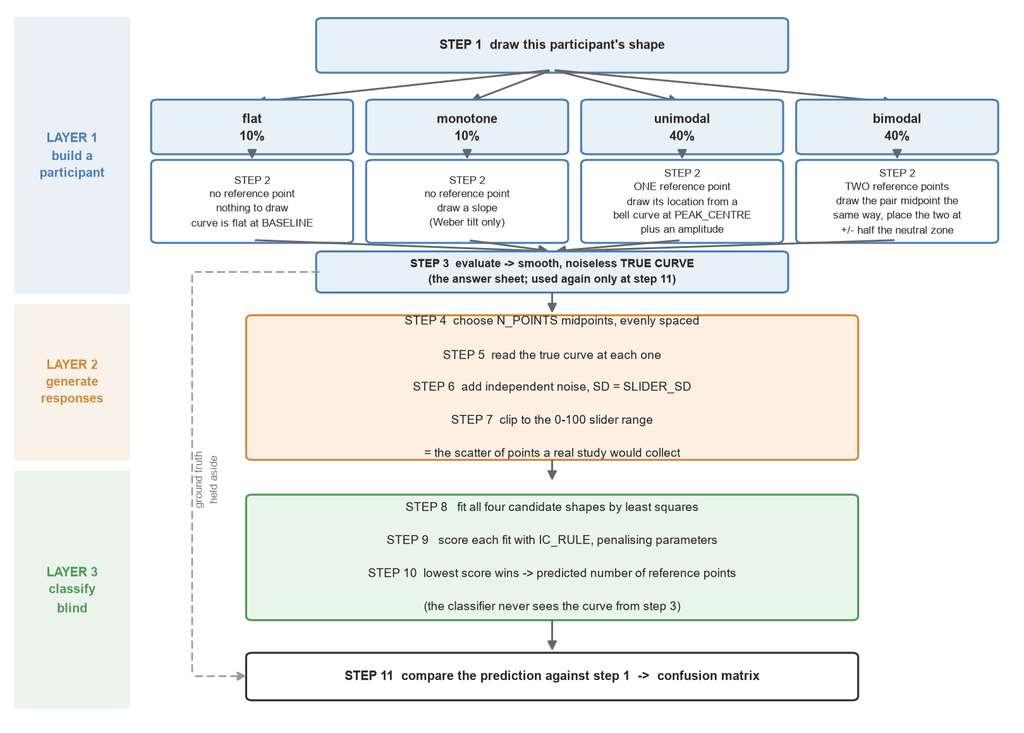

```python
from matplotlib.patches import FancyBboxPatch, FancyArrowPatch

fig, ax = plt.subplots(figsize=(8.6, 6.2))
ax.set_xlim(0, 100); ax.set_ylim(0, 100); ax.axis('off')

C_L1, C_L2, C_L3 = '#e8f0f8', '#fdf0e2', '#e9f5ea'
E_L1, E_L2, E_L3 = '#4a7fb5', '#d08a3e', '#4f9a58'

def box(x, y, w, h, text, fc, ec, fs=7.0, weight='normal'):
    ax.add_patch(FancyBboxPatch((x, y), w, h, boxstyle="round,pad=0.6",
                                linewidth=1.2, facecolor=fc, edgecolor=ec))
    ax.text(x + w / 2, y + h / 2, text, ha='center', va='center',
            fontsize=fs, weight=weight, linespacing=1.45)

def arrow(x1, y1, x2, y2, color='#666', label=None):
    ax.add_patch(FancyArrowPatch((x1, y1), (x2, y2), arrowstyle='-|>',
                                 mutation_scale=11, linewidth=1.1, color=color))
    if label:
        ax.text((x1 + x2) / 2 + 1.5, (y1 + y2) / 2, label, fontsize=6.8,
                color='#333', ha='left', va='center', weight='bold')

for y0, y1_, lab, col in ((60.5, 99, 'LAYER 1\nbuild a\nparticipant', E_L1),
                          (37, 58.5, 'LAYER 2\ngenerate\nresponses', E_L2),
                          (2, 35, 'LAYER 3\nclassify\nblind', E_L3)):
    ax.add_patch(FancyBboxPatch((0.5, y0), 11, y1_ - y0, boxstyle="round,pad=0.3",
                                linewidth=0, facecolor=col, alpha=.11))
    ax.text(6, (y0 + y1_) / 2, lab, ha='center', va='center', fontsize=7.6,
            weight='bold', color=col, linespacing=1.5)

box(31, 92, 46, 6.5, "STEP 1  draw this participant's shape", C_L1, E_L1, 7.6, 'bold')

_order = ['flat', 'monotone', 'unimodal', 'bimodal']
_pct = {k: SHAPE_MIX.get(k, 0) for k in _order}
_ref = {'flat': 'no reference point', 'monotone': 'no reference point',
        'unimodal': 'ONE reference point', 'bimodal': 'TWO reference points'}
_par = {'flat': 'nothing to draw\ncurve is flat at BASELINE',
        'monotone': 'draw a slope\n(Weber tilt only)',
        'unimodal': 'draw its location from a\nbell curve at PEAK_CENTRE\nplus an amplitude',
        'bimodal': 'draw the pair midpoint the\nsame way, place the two at\n+/- half the neutral zone'}
xs_b = [14.5, 36, 57.5, 79]
for xb, nm in zip(xs_b, _order):
    arrow(54, 91.8, xb + 9.5, 87.2)
    box(xb, 80.5, 19, 6.5, f"{nm}\n{_pct[nm]:.0%}", C_L1, E_L1, 7.6, 'bold')
    box(xb, 68, 19, 10.5, f"STEP 2\n{_ref[nm]}\n{_par[nm]}", '#ffffff', E_L1, 6.2)
    arrow(xb + 9.5, 80.3, xb + 9.5, 78.7)
    arrow(xb + 9.5, 67.8, 54, 66.2)

box(31, 61, 46, 4.6,
    "STEP 3  evaluate -> smooth, noiseless TRUE CURVE\n(the answer sheet; used again only at step 11)",
    C_L1, E_L1, 6.9, 'bold')
arrow(54, 60.8, 54, 57.0)

box(24, 37.4, 60, 19.2,
    "STEP 4  choose N_POINTS midpoints, evenly spaced\n\n"
    "STEP 5  read the true curve at each one\n\n"
    "STEP 6  add independent noise, SD = SLIDER_SD\n\n"
    "STEP 7  clip to the 0-100 slider range\n\n"
    "= the scatter of points a real study would collect",
    C_L2, E_L2, 7.2)
arrow(54, 37.2, 54, 33.4)
box(24, 14.8, 60, 16.5,
    "STEP 8   fit all four candidate shapes by least squares\n\n"
    "STEP 9   score each fit with IC_RULE, penalising parameters\n\n"
    "STEP 10  lowest score wins -> predicted number of reference points\n\n"
    "(the classifier never sees the curve from step 3)",
    C_L3, E_L3, 7.2)
arrow(54, 14.6, 54, 9.4)

box(24, 3.5, 60, 5.5,
    "STEP 11  compare the prediction against step 1  ->  confusion matrix",
    '#ffffff', '#333333', 7.4, 'bold')
ax.add_patch(FancyArrowPatch((31, 63.3), (18, 63.3), arrowstyle='-',
                             linewidth=1.0, color='#999', linestyle=(0, (4, 3))))
ax.add_patch(FancyArrowPatch((18, 63.3), (18, 6.3), arrowstyle='-',
                             linewidth=1.0, color='#999', linestyle=(0, (4, 3))))
ax.add_patch(FancyArrowPatch((18, 6.3), (23.8, 6.3), arrowstyle='-|>',
                             mutation_scale=11, linewidth=1.0, color='#999',
                             linestyle=(0, (4, 3))))
ax.text(19.4, 34, 'ground truth\nheld aside', fontsize=6.4, color='#777',
        rotation=90, ha='center', va='center', linespacing=1.4)
plt.tight_layout()
plt.show()
```

**NoteHow many participants?**

The number of participants does **not** change the error rates. Each participant is classified using only their own data, so the chance of getting one wrong depends on that participant alone. What `N_PEOPLE` sets is how precisely those rates are *estimated*. Because Type II error is measured only on participants who truly have two reference points — 40% of the sample under the current `SHAPE_MIX` — the useful sample is smaller than `N`:

| `N_PEOPLE` | two-reference-point participants | 95% margin on Type II |
| --- | --- | --- |
| 200 | 80 | ± 7.5 points |
| 500 | 200 | ± 4.7 points |
| 1000 | 400 | ± 3.3 points |
| 2000 | 800 | ± 2.4 points |

The ordinary binomial margin is exact here, not an approximation: participants are drawn independently, so their classification outcomes are independent draws whose shared success probability is already the population average. §10 sweeps 200 to 500 and confirms the rates stay flat within these margins.